# Visualizing Covid-19

# From epidemic to pandemic¶

In December 2019, COVID-19 coronavirus was first identified in the Wuhan region of China. By March 11, 2020, the World Health Organization (WHO) categorized the COVID-19 outbreak as a pandemic. A lot has happened in the months in between with major outbreaks in Iran, South Korea, and Italy.

We know that COVID-19 spreads through respiratory droplets, such as through coughing, sneezing, or speaking. But, how quickly did the virus spread across the globe? And, can we see any effect from country-wide policies, like shutdowns and quarantines?

Fortunately, organizations around the world have been collecting data so that governments can monitor and learn from this pandemic. Notably, the Johns Hopkins University Center for Systems Science and Engineering created a publicly available data repository to consolidate this data from sources like the WHO, the Centers for Disease Control and Prevention (CDC), and the Ministry of Health from multiple countries.

In this notebook, you will visualize COVID-19 data from the first several weeks of the outbreak to see at what point this virus became a global pandemic.

```r
library(readr)
library(ggplot2)
library("dplyr")
library(coronavirus)
update_dataset()
```

```
No updates are available
```

```r
# Read datasets/confirmed_cases_worldwide.csv into confirmed_cases_worldwide
path <- getwd()
path <- file.path(path, "datasets", "confirmed_cases_worldwide.csv")
confirmed_cases_worldwide <- read_csv(path)
# See the result
confirmed_cases_worldwide
```

| date | cum_cases |
| --- | --- |
| 2020-01-22 | 555 |
| 2020-01-23 | 653 |
| 2020-01-24 | 941 |
| 2020-01-25 | 1434 |
| 2020-01-26 | 2118 |
| 2020-01-27 | 2927 |
| 2020-01-28 | 5578 |
| 2020-01-29 | 6166 |
| 2020-01-30 | 8234 |
| 2020-01-31 | 9927 |

[output cut: 46 more lines]

# Confirmed cases throughout the world

The table above shows the cumulative confirmed cases of COVID-19 worldwide by date. Just reading numbers in a table makes it hard to get a sense of the scale and growth of the outbreak. Let’s draw a line plot to visualize the confirmed cases worldwide.

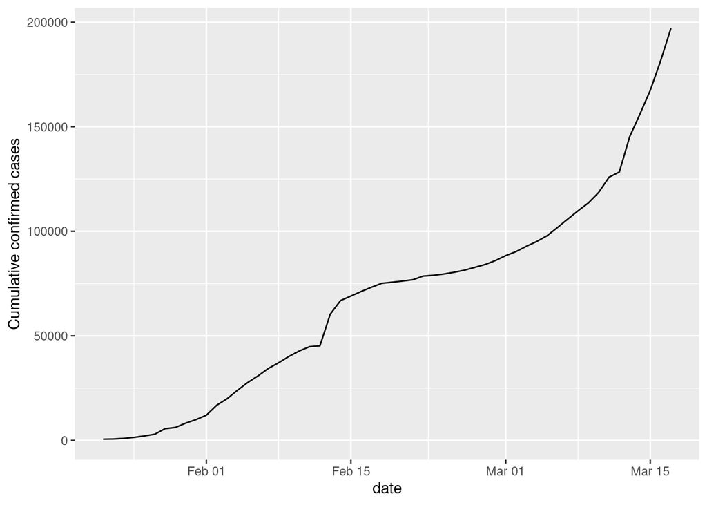

```r
# Draw a line plot of cumulative cases vs. date
# Label the y-axis
confirmed_cases_worldwide %>%
    ggplot(
        aes(
            x=date,
            y=cum_cases
        )
    ) +  geom_line() + ylab("Cumulative confirmed cases")
```